# Week 5 - Supervised learning

Gareth Gillard, Lars Grønvold, Niklas Mähler, Torgeir R. Hvidsten

Last change: 28.09.2024

## Introduction

In the previous lab we looked at clustering, which is also referred to as unsupervised learning. Now we will take a look at [supervised learning](https://en.wikipedia.org/wiki/Supervised_learning). Supervised learning differs from unsupervised learning in the sense these methods take advantage of known classes (the data is labelled). Typically, we separate our data into a training set and a test set. The training set is used for training a model and and the test set is used test if the model generalizes to unknown observations. Supervised learning is also known as machine learning.

**OBS**: Some parts of this exercise is a tutorial where you only have to copy and run the code. Don’t be content with that: try to understand what the code does! In the R Markdown report, only include code and results that are needed to document what you are asked to produce yourself (in red). Also remember to answer all questions in red.

## Data

Machine learning generally require many observations to be effective, especially when the number of features (typically genes in functional genomics) range in the tens of thousands. We will therefore use cancer data from the fantastic data repository provided by [the National Cancer Insitiute in the US](https://portal.gdc.cancer.gov). In particular, we will look at data from the [The Cancer Genome Atlas (TCGA) Research Network](https://www.nature.com/articles/ng.2764) that is producing multi-omics data. We will only use RNA-Seq data in this lab. As many large-scale projects, they have created an R interface to the data - called [TCGAbiolinks](http://bioconductor.org/packages/release/bioc/html/TCGAbiolinks.html).

Below there is some code to download read count data. **This code takes a looooong time to run, so instead of running the code you should download the count table that the code produces from Canvas: `TCGA.RData`.**

```r
if (!requireNamespace("BiocManager", quietly = TRUE))
  install.packages("BiocManager")
BiocManager::install("TCGAbiolinks")

library(TCGAbiolinks)
library(SummarizedExperiment)

# View all projects
# View(TCGAbiolinks:::getGDCprojects())

counts <- data.frame()
samples <- c()
classes <- c()

# Download RNA-Seq data for selected projects
tissue <- c("Breast", "Kidney", "Colon", "Lung", "Prostate","Lymphocytes", "Skin", "Bladder","Stomach", "Brain","Ovary","Pancreas","Rectum")
proj   <- c("TCGA-BRCA", "TCGA-KIRC", "TCGA-COAD", "TCGA-LUAD", "TCGA-PRAD", "TCGA-DLBC",
            "TCGA-SKCM", "TCGA-BLCA", "TCGA-STAD", "TCGA-GBM", "TCGA-OV", "TCGA-PAAD", "TCGA-READ")
for (i in 1:length(proj)) {

  query <- GDCquery(project = proj[i],
                    data.category = "Transcriptome Profiling",
                    data.type = "Gene Expression Quantification",
                    workflow.type = "STAR - Counts")

  GDCdownload(query, method = "api", files.per.chunk = 10)

  data <- GDCprepare(query, )
  tmp.counts <- assays(data)$unstranded
  tmp.samples <- paste(tissue[i], colData(data)$primary_diagnosis, sep="-")

  # Sample must have 20M reads
  idx <- colSums(tmp.counts) > 20E6
  tmp.counts <- tmp.counts[,idx]
  tmp.samples <- tmp.samples[idx]

  # Randomly select 200 samples
  if (ncol(tmp.counts) > 200) {
    idx <- sample(1:ncol(tmp.counts), 200)
    tmp.counts <- tmp.counts[,idx]
    tmp.samples <- tmp.samples[idx]
  }

  if (nrow(counts) == 0) {
    counts <- tmp.counts
  } else {
    counts <- cbind(counts, tmp.counts)
  }
  samples <- c(samples, tmp.samples)
  classes <- c(classes, rep(tissue[i], length(tmp.samples)))
}
remove(tmp.counts, tmp.samples)
classes <- factor(classes)

table(classes)
dim(counts)

# Filtering
# Genes must have 1024 mapped reads in at least 10 samples
counts <- counts[rowSums(counts > 2^10) > 10,]
dim(counts)

save(counts, classes, file = "TCGA.RData")
```

Load the data:

```r
load(file = "TCGA.RData")
```

You will get two objects:

- `counts`: A read count table
- `classes`: A vector with class labels for the columns in `expr`.

Now, explore the data:

- How many genes and samples are in the dataset? Hint: `dim`.
- How many samples are there for each class? Hint: `table`.

The dataset is too big for machine learning algorithms in a short lab - even normalization and PCA takes a long time. Below is a PCA plot of the VST-normalized expression data:

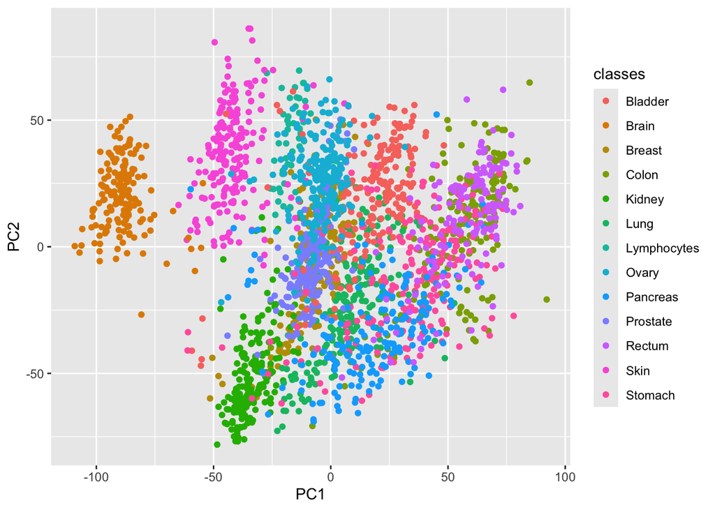

Let’s select some classes that look difficult to separate and remove lowly expressed genes:

```r
idx <- classes %in% c("Colon", "Rectum", "Stomach")

classes <- classes[idx] %>% factor()
counts <- counts[, idx]

# Genes must have 1024 mapped reads in at least 10 samples
counts <- counts[rowSums(counts > 2^10) > 10,]
dim(counts)
```

```
## [1] 13007   544
```

The data we have is raw counts and needs to be normalized:

- Use DESeq2 to compute VST expression values (see Lab 2). This will take a couple of minutes (30 seconds on my powerful laptop). Name the VST-normalized expression table `expr`.

The data set is still pretty big for some of the algorithms we are using. Let’s further reduce the number of genes by selecting those that have variable expression across individuals:

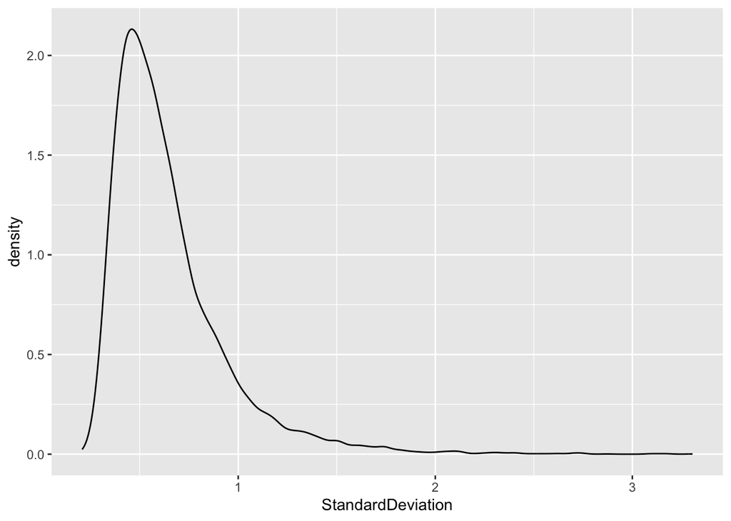

```r
library(matrixStats)

standard.deviations = rowSds(expr)

tibble(StandardDeviation = standard.deviations) %>%
  ggplot(aes(x = StandardDeviation)) +
  geom_density()
```

```r
expr <- expr[standard.deviations > 1.5,]
dim(expr)
```

```
## [1] 275 544
```

- Produce a PCA plot and color the samples according to `classes` (see Lab 4). Hint: The `prcomp` function operate on the rows i.e. the rows will be points in the PCA plot with principle components as axes. Based on the PCA plot, do you think it will be easy or hard to classify these samples using machine learning?

Now we are almost ready to do some machine learning, but read this first:

## A word on sequence generation

In this lab, you might need the function `seq`. Take a moment to experiment. Here are some examples:

```r
1:5
```

```
## [1] 1 2 3 4 5
```

```r
seq(1, 5)
```

```
## [1] 1 2 3 4 5
```

```r
seq(1, 5, by = 0.5)
```

```
## [1] 1.0 1.5 2.0 2.5 3.0 3.5 4.0 4.5 5.0
```

## A theoretical example of overfitting

$$y = 3x^3 + 5x^2 + 0.5x + 2 +
\epsilon$$

where $\epsilon$ is an error term. The “real” underlying model is represented by the red line, and a simple linear model (degree 1) by the green line and a complicated (degree 15) model by the blue line. As you can see, the linear model does not explain the data very well. It doesn’t even match our training data, and it won’t work well at all. This can be seen as underfitting. The degree 15 model matches the training data really well, but on the other hand, if we would add more data generated by the function above (test data), it wouldn’t generalize well at all, and is an example of overfitting.

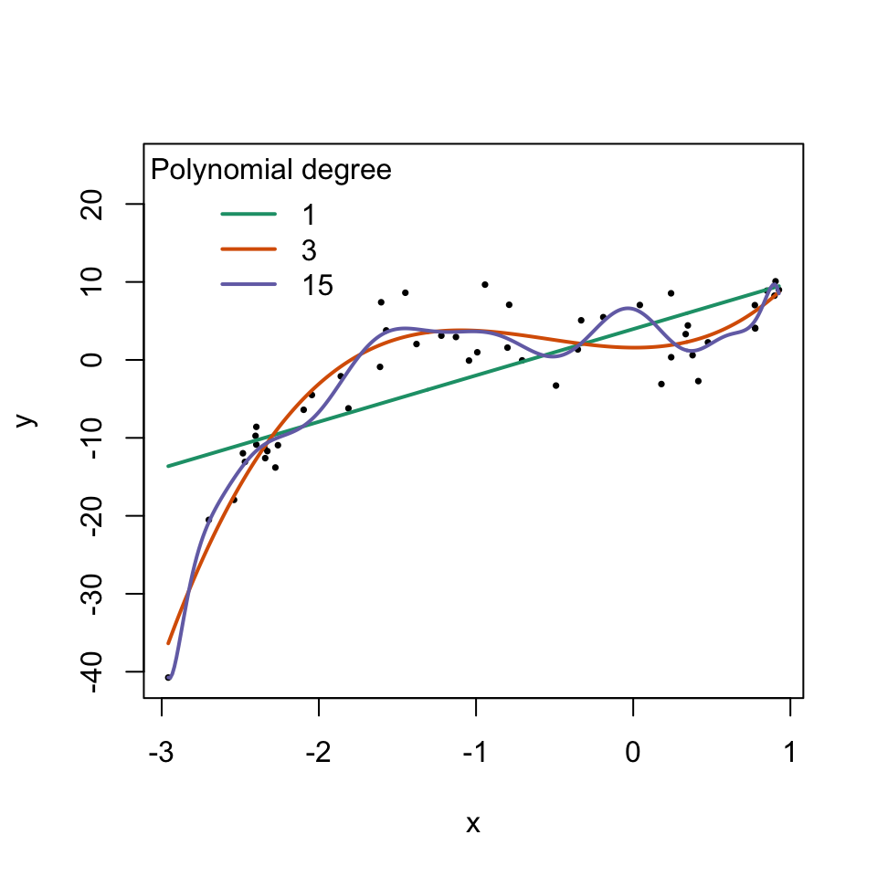

We can divide the dataset into two parts, one for training and one for testing, we can then build the model using the training data and test how well it generalized with the test data. In the figure below we have done this for 15 different models of different complexity (in our case polynomial degree). For each model we plot the mean absolute error for the training and test data (i.e. the mean distance between the points from the dataset and from the model). In addition, we combine this with a 10-fold cross validation (see the next section for more details).

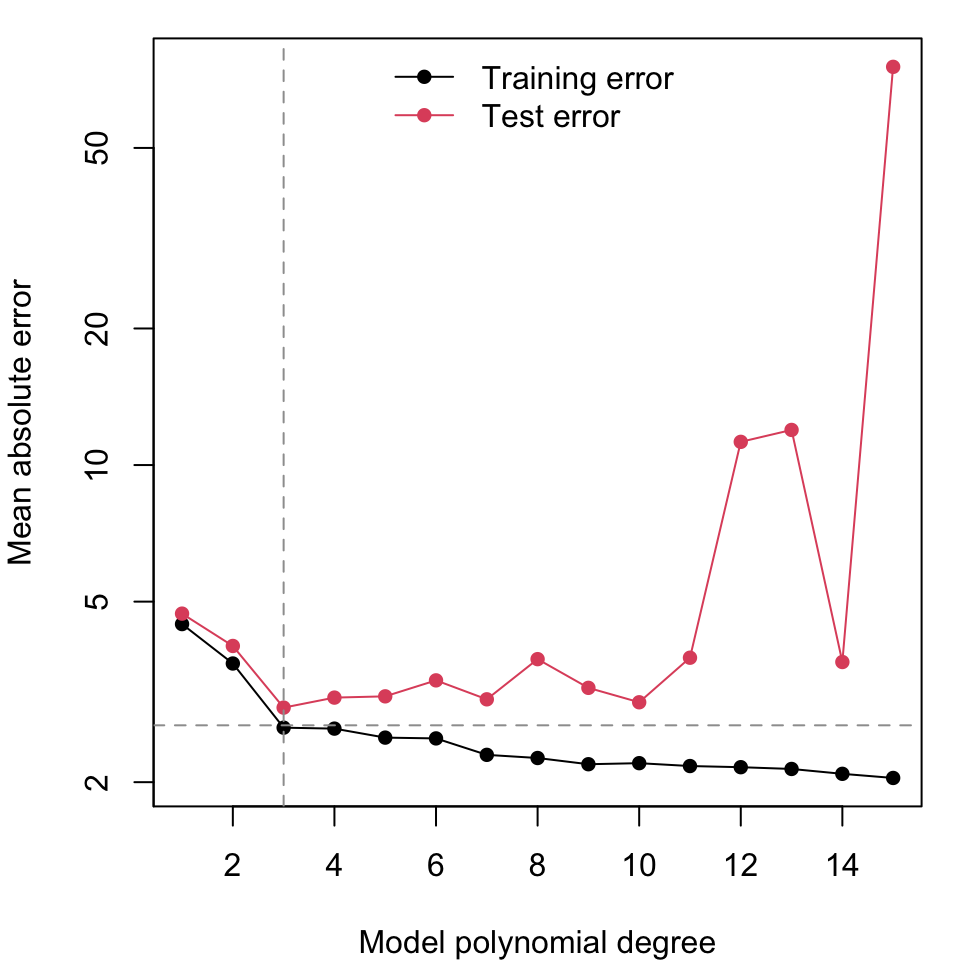

## Cross Validation

Cross validation is a method that can be used to test for overfitting. The principle is that you run the classification several times so that each observation has been part of the test set. If you run the `cv.ani` function in the `animation` package, you’ll see a simple animation on how a 10-fold cross validation works. OBS: Make sure you have selected the `Plots` tab in RStudio and run the animation in the Console window.

```r
install.packages("animation")
library(animation)
animation::cv.ani()
```

In a 10-fold cross validation, as above, you will get a prediction result for each combination of training and test data. The classification error can then be averaged across these results to see how the model performs.

## The Caret package

The `Caret` package provides a uniform interface to a number of different machine learning methods. A typical work flow looks something like this:

- Use `createDataPartition()` to divide the data into a training set and a test set.
- Use `train()` to train a model on the training set. Typically this includes using cross validation to select so-called hyperparameters. For example, $k$ in nearest neighbor classifiers is a hyperparameter: training in this case means testing different values for $k$ using cross validation and selecting the value with the highest accuracy. This value is then used in the final model.
- Use `predict()` to predict classes for the observations in the test set, using the final model.

Let’s use `Caret` to do $k$-nearest neighbors supervised learning on the iris-dataset:

## $k$-Nearest Neighbors ($k$-NN)

One very simple, but often surprisingly effective supervised learning method is $k$-Nearest Neighbors, or $k$-NN. What it does is that for each sample in the test data, it checks the $k$ nearest neighbors in feature space and assigns the observation to the class that shows up the most among the $k$ neighbors.

If you run the `knn.ani` function from the `animation` package, you can see a small animation on how it works:

```r
animation::knn.ani()
```

### An example using the iris dataset

In the context of the iris dataset, we will train a model that can predict the species of a plant from its sepal and petal lengths and widths. Use `View(iris)` to remind yourself of the structure of the iris dataset.

Then install the `caret` package.

First, we’ll need to split the iris dataset into a training and a test set:

```r
library(caret)
set.seed(3)

idxTrain <- createDataPartition(y = iris$Species, p = 0.5, list = FALSE)
iris.train <- iris[idxTrain,]
iris.test <- iris[-idxTrain,]
```

Now that we have set up the data, we can can train a $k$-NN “model”. I write “model” in quotation marks because this method is so simple that it doesn’t really produce a model, but we need to find a good value for the hyperparameter $k$.

Notice the syntax `form = Species ~ ., data = iris.train`. This can be read as: “Predict the variable `Species` using all the other variables in the data set `iris.train`”.

```r
iris.knn.model <- train(form = Species ~ .,
                        data = iris.train,
                        method = "knn",
                        trControl = trainControl(method = "cv"),
                        tuneGrid = data.frame(k = 2:15))

iris.knn.model
```

```
## k-Nearest Neighbors
##
## 75 samples
##  4 predictor
##  3 classes: 'setosa', 'versicolor', 'virginica'
##
## No pre-processing
## Resampling: Cross-Validated (10 fold)
## Summary of sample sizes: 66, 68, 68, 69, 67, 68, ...
## Resampling results across tuning parameters:
##
##   k   Accuracy   Kappa
##    2  0.9607143  0.9402281
##    3  0.9607143  0.9402281
##    4  0.9607143  0.9402281
##    5  0.9607143  0.9402281
##    6  0.9732143  0.9592757
##    7  0.9732143  0.9592757
##    8  0.9732143  0.9592757
##    9  0.9607143  0.9402281
##   10  0.9607143  0.9402281
##   11  0.9607143  0.9402281
##   12  0.9607143  0.9402281
##   13  0.9607143  0.9402281
##   14  0.9607143  0.9402281
##   15  0.9607143  0.9402281
##
## Accuracy was used to select the optimal model using the largest value.
## The final value used for the model was k = 8.
```

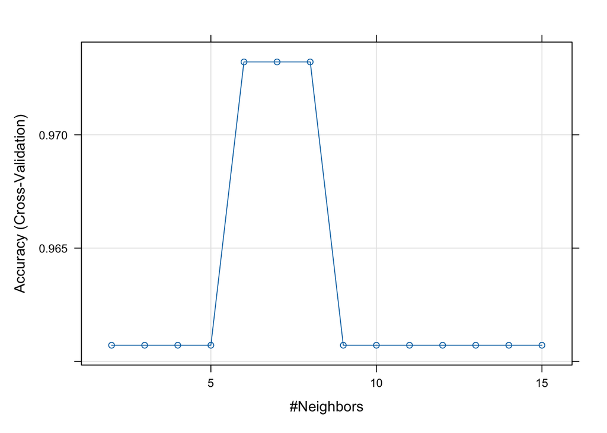

```r
plot(iris.knn.model)
```

Briefly explain the output (text and plot) in the context of the input parameters to `train()`

We can now predict the species of the plants in the test set:

```r
iris.knn.pred <- predict(iris.knn.model, iris.test)
iris.knn.pred
```

```
##  [1] setosa     setosa     setosa     setosa     setosa     setosa
##  [7] setosa     setosa     setosa     setosa     setosa     setosa
## [13] setosa     setosa     setosa     setosa     setosa     setosa
## [19] setosa     setosa     setosa     setosa     setosa     setosa
## [25] setosa     versicolor versicolor versicolor versicolor versicolor
## [31] versicolor versicolor versicolor versicolor versicolor versicolor
## [37] versicolor versicolor versicolor versicolor versicolor versicolor
## [43] versicolor versicolor versicolor versicolor versicolor versicolor
## [49] versicolor versicolor virginica  virginica  virginica  virginica
## [55] virginica  virginica  virginica  virginica  virginica  virginica
## [61] virginica  versicolor virginica  virginica  virginica  virginica
## [67] virginica  virginica  virginica  virginica  virginica  virginica
## [73] virginica  virginica  virginica
## Levels: setosa versicolor virginica
```

And finally we can compare the predicted species to the correct species to see how well the classification performed. For this we create a confusion matrix like we did in the previous lab. We can also use the confusion matrix to compute performance measures such as accuracy and error rate:

```r
confusion <- table(iris.test$Species, iris.knn.pred, dnn = c("Real", "Predicted"))
confusion
```

```
##             Predicted
## Real         setosa versicolor virginica
##   setosa         25          0         0
##   versicolor      0         25         0
##   virginica       0          1        24
```

```r
accuracy <- sum(diag(confusion)) / sum(confusion)
accuracy
```

```
## [1] 0.9866667
```

```r
error <- 1 - accuracy
error
```

```
## [1] 0.01333333
```

As you can see, the method performs really well on this data.

### $k$-NN on the cancer RNA-Seq data

Now it’s your turn to run $k$-NN on the normalized cancer RNA-Seq data. See if the methods is able to classify samples into the three cancer types using gene expression.

Its a really good idea to start by creating a version of the cancer expression data that looks like the iris data:

```r
expr_t <- expr %>%
  t() %>%
  as.data.frame() %>%
  mutate(Class = classes)
```

Run $k$-NN on the cancer data:

- Try some different values of $k$.
- Present the predictions as a confusion matrix. What’s your conclusion about classifying cancer types from RNA-Seq data so far?

## Random forest

A popular and powerful machine learning method is Random Forest. This method computes a *forest* of so called *decision trees*, each of which combines a set of features (in our case genes) to differentiate the classes.

Each decision tree is computed based on a random subset of observations and tested on the remaining observations. The method therefore contains a built in, repeated division into training and test sets.

Random forest methods can also outputs the *importance* of each feature: the prediction accuracy of the forest is tested with and without each feature, and the features are then ranked by how important they are for prediction.

Caret also includes a random forest method, but here we will use the popular package `randomForest`:

### An example using the iris dataset

```r
# Install the following package
library(randomForest)

iris.rf.model <-  randomForest(Species ~ .,
                               data = iris,
                               importance=TRUE,
                               ntree=1000)

confusion <- table(iris$Species, iris.rf.model$predicted, dnn = c("Real", "Predicted"))
confusion
```

```
##             Predicted
## Real         setosa versicolor virginica
##   setosa         50          0         0
##   versicolor      0         47         3
##   virginica       0          3        47
```

```r
accuracy <- sum(diag(confusion)) / sum(confusion)
accuracy
```

```
## [1] 0.96
```

```r
iris.rf.model %>%
  importance() %>%
  as.data.frame() %>%
  rownames_to_column(var = "Variables") %>%
  arrange(desc(MeanDecreaseAccuracy)) %>%
  select(Variables, MeanDecreaseAccuracy)
```

```
##      Variables MeanDecreaseAccuracy
## 1 Petal.Length            48.124182
## 2  Petal.Width            47.717498
## 3 Sepal.Length            16.055108
## 4  Sepal.Width             7.648781
```

### Random forest on the cancer RNA-Seq data

Now it’s your turn to run Random Forest on the normalized cancer RNA-Seq data.

As we have seen, random forest gives estimates of the importance of each variable (i.e. gene) for prediction. Download the file *genenames.org.txt* from Canvas. This file was obtained from https://www.genenames.org.

Produce a similar table to the one below (Hint: Use `separate` and `left_join`):

```
##              Genes MeanDecreaseAccuracy   Symbol
## 1  ENSG00000159184             19.01482   HOXB13
## 2  ENSG00000225840             17.21879     <NA>
## 3  ENSG00000225972             16.35214 MTND1P23
## 4  ENSG00000159182             15.73498    PRAC1
## 5  ENSG00000251562             14.98275   MALAT1
## 6  ENSG00000136574             14.97338    GATA4
## 7  ENSG00000169605             13.33102     GKN1
## 8  ENSG00000168631             12.68273    MUCL3
## 9  ENSG00000167996             12.54199     FTH1
## 10 ENSG00000137634             11.97737    NXPE4
```

Paste the first 10 gene symbols into your favorite chatbot and ask it to explain why these genes could be relevant - in less than 100 words. Are you convinced?

Plot the expression of some of the top 10 most predictive genes as boxplots, e.g.:

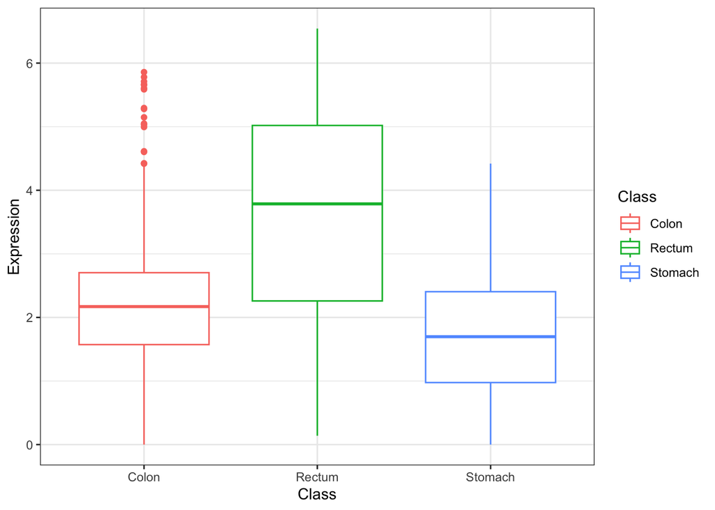

## Deep learning

[Deep learning](https://en.wikipedia.org/wiki/Deep_learning) is a group of machine learning methods that uses multi-layered artificial neural networks. Here we will only look at very simple feed-forward neural networks trained using the [backpropagation algorithm](https://www.geeksforgeeks.org/backpropagation-in-neural-network/).

Let’s look at an example first.

### An example using the iris dataset

This is an example of a multi-layered artificial neural networks trained on the iris data:

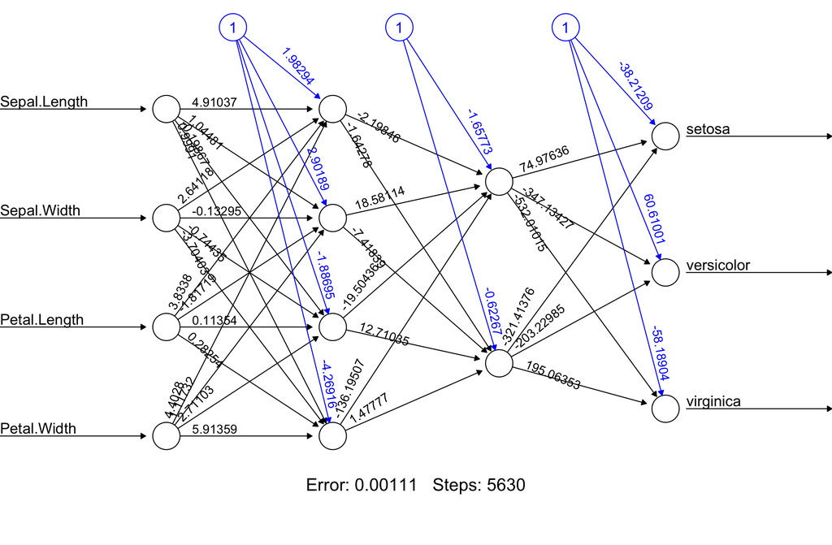

From the plot: Explain the architecture of the network: how many nodes are in the input layer, hidden layers and output layers? Why?

The architecture of a neural network (hyperparameters: number and size of the hidden layers) is very important for the performance, and finding the right architecture might take a lot of computational resources.

Here we will restrict ourselves to a single hidden layer, and use `Caret` to find the number of nodes in this layer (using the `size`-parameter):

```r
# Install package RSNNS, but do not use library(RSNNS) to load it.

iris.mlp.model <- train(Species ~ .,
                        data = iris.train,
                        method = "mlp",
                        trControl = trainControl(method = "cv", number = 5),
                        tuneGrid = data.frame(size = 1:10))

iris.mlp.model
```

```
## Multi-Layer Perceptron
##
## 75 samples
##  4 predictor
##  3 classes: 'setosa', 'versicolor', 'virginica'
##
## No pre-processing
## Resampling: Cross-Validated (5 fold)
## Summary of sample sizes: 60, 60, 60, 60, 60
## Resampling results across tuning parameters:
##
##   size  Accuracy   Kappa
##    1    0.7333333  0.60
##    2    0.9466667  0.92
##    3    0.9600000  0.94
##    4    0.8800000  0.82
##    5    0.9733333  0.96
##    6    0.9600000  0.94
##    7    0.9866667  0.98
##    8    0.9066667  0.86
##    9    0.9600000  0.94
##   10    0.9733333  0.96
##
## Accuracy was used to select the optimal model using the largest value.
## The final value used for the model was size = 7.
```

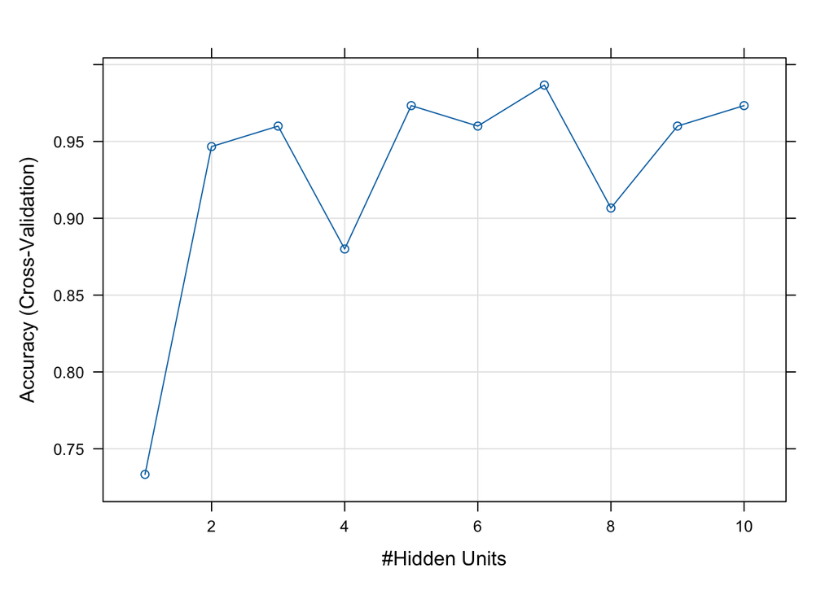

```r
plot(iris.mlp.model)
```

```r
iris.mlp.pred <- predict(iris.mlp.model, iris.test)

confusion <- table(iris.test$Species, iris.mlp.pred, dnn = c("Real", "Predicted"))
confusion
```

```
##             Predicted
## Real         setosa versicolor virginica
##   setosa         25          0         0
##   versicolor      0         25         0
##   virginica       0          8        17
```

```r
accuracy <- sum(diag(confusion)) / sum(confusion)
accuracy
```

```
## [1] 0.8933333
```

### Deep learning on the cancer RNA-Seq data

Try deep learning on the cancer data.

What are the number of nodes in the input and the output layer when using the cancer data? You will need a bigger hidden layer than for the iris data. Try some values between 10 and 100 (here the `seq`-function can be very useful!). Testing 10 values took 2 minutes on my computer.

The maybe underwhelming performance of neural networks in this exercise is probably due to the limited size of the network. There are considerably more advanced deep learning methods around, that allow for more than one hidden layer. Consider testing *library(keras3)* for the project later on in the course.

## Optional: Support vector machines (SVMs)

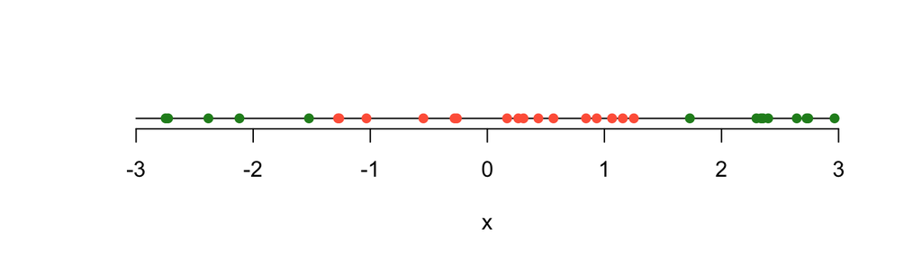

There is no way you can draw a single straight line (or more accurately, find a single threshold) that perfectly separates these two classes. However, if we add an extra “artificial” dimension that simply is a transformation of $x$, i.e. $y = x^2$, then it is possible to separate the two classes:

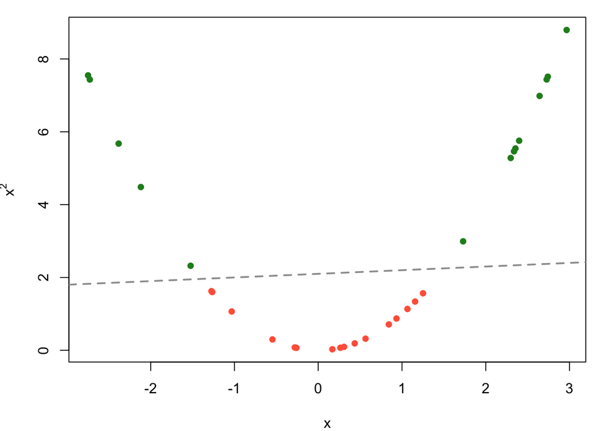

This is a very simplified demonstration of what an SVM is trying to achieve with its so-called kernel trick.

### An example using the iris dataset

We can use the training and test datasets that we generated earlier using the iris data.

```r
# Install and load the library with svm function
library(e1071)

# Train the model using the training data
iris.svm.model <- svm(Species ~ ., iris.train)

# Use the model to predict the classes for the test data
iris.svm.pred <- predict(iris.svm.model, iris.test)

# Create a confusion matrix
confusion <- table(iris.test$Species, iris.svm.pred, dnn = c("Real", "Predicted"))
confusion
```

```
##             Predicted
## Real         setosa versicolor virginica
##   setosa         25          0         0
##   versicolor      0         25         0
##   virginica       0          2        23
```

```r
# Accuracy
accuracy <- sum(diag(confusion)) / sum(confusion)
accuracy
```

```
## [1] 0.9733333
```